# Week 10 2025-09-15 to 2025-09-21

Author

Tobias Nunn

Published

September 21, 2025

# Introduction

This week is a direct continuation of the stuff I was doing last week. To recap, last week I completed these steps in my plan:

1. log back onto hawk SCW ✅
2. clean up my space on hawk ✅
3. figure out how to clone my github repo up there (so I do not have to manually download any scripts) ✅
4. figure out how to run R from the command line on Hawk ✅
   1. I know how to run a script through the terminal, i do it for my “create_notebooks.R” script ✅
   2. As a part of this, I want to figure out how to run an R script from slurm, may be useful ✅

Which means that these are the steps I will do in the next few weeks:

1. create a script that will download the .fasta files directly to hawk
   1. this cuts out storing them on my machine, its more efficient
   2. I will be downloading both the genomic and protein fastas as I do not know which to use
2. At first, the script will only do a few accessions ✅
   1. this means I can compare genomic fastas that I process through prodigal to their protein fastas, if they are the same, then I might as well save the time and use theirs, when I download them all. ✅
3. Regardless of the results from that mini-experiment, I will set-up a script or some pipeline for turning genomic fastas into protein fastas❓
   1. this could still be useful in future, i.e. if Aaron gives me more genomes from Alberto, he wont have the protein fastas, so I might as well already have that pipeline ready
   2. I will need to decide if I want to do this through bash or R and command line or slurm
4. I will need to figure out how to store the results of the fasta-downloading script
   1. i.e. do I do more .rds, would that work on hawk? should it be a list object?
      1. I think yes to both, but I’ll see when I get there
      2. A good idea is to test that on my machine before doing it on hawk, more visual so I know better what is actually happening
      3. another thing to say is that the ideal formatting for blast p vs eggnogmapper is probably different, so I may need to store the protein or genomic fastas differently depending on what tool they are about to be processed by.

There are two weeks until term start again, and I would at least like to be mostly done with this phase of work by then. As well as this project, I have to prepare for an unrelated small presentation I am doing, so I will need to focus up to get all of this done. I also created a list of next steps last week, this can be thought of as a next level down to the above list, as in, things I need to do either before or during the first element:

NEXT STEPS: add a progress bar to the loop for fun, file is going to need to be modified in order to run on Hawk(relative file paths will need to be modified), add text to the readme and .gitkeep for 01_inputs/04_fastas to explain why that file exists but is empty, at some point later on, I will combine all the .rds files for each individual accession into mega-rds files based on genus. I also realise I will need to upload the secrets file manually to hawk as it would not have copied in the clone, also, to fix the relative file paths thing using the “here” package.

# Methods

#### trial and error with getting stuff on hawk

I started this week by finishing the content from last week. I populated the “results section”, this was just to consolidate what I had done. I did a lot last week and I do not want to find myself over extending and finding that I went too quick (with the help of Claude.ai) that I do not understand what I have done. Then, I will begin working through my NEXT STEPS list.

I found out that you can put a “.here” file in (just a blank text file with the name “.here”) the directory you wish the relative path to start from. Putting this in 06_notebooks, means that I do not have to edit any existing file paths, and it should mean it will work equally on hawk and my machine. I do need to wrap all file paths in here::here() for this system to work, but only when they are being used, not when they are being created. After some error, I found that the .here file needs to be above where the package is looking for it (i.e. in the root directory “undergrad_dissertation”. This means the file paths are going to need to be updated to come from there, as in, I will have to take out the “../” on the front, and replace it with “./”. I do not think I need to do this recursively for all scripts (especially those that are not planned to be run on hawk) as the relative file path should only source from the .here when I wrap a file path in here::here. This means for file paths that will only run on my machine, I can skip using here and just let the relative file path come from the .proj file.

Right, that is all way too complicated, and worse, it doesnt even work. So I am biting the bullet and just moving the .Rproj file to the root, which means I am going to need to recursively change all file paths, but at this point I think this is the only thing that will work. I used this as an opportunity to clean up and archive old stuff. I took out the scripts under “01_…” and “02_…”, because they were legacy code from before I decided to start again (again). So, I just removed numbers completely, which means I will have to more manually remember the order of files. I still need here() for the relative file paths, but it looks a lot less insane now, I did not have to do it on as many files as I thought, because I archived all the legacy scripts. I have modified “test_coomand_line.R” now so that it is a test of whether here() will chose to work on hawk, this is what I will test next, before moving onto the proper “fastafile_getter.R” script.

After loading onto hawk I found that the here package was not installed, so I am going to have to install it myself. After a fair bit of effort, I managed to make the test script work. In order to do this, I needed to:

1. I created an area in my home directory called “/R/library/”
2. do a “`module load R/4.4.2`
3. I created an R session by typing “`R`” in the console
4. I loaded a CRAN mirror using the code “`options(repos = c(CRAN = "https://cloud.r-project.org/"))`”
5. I typed “`install.packages("here",lib="~/R/library")`” to install here
6. I closed the R session with “`q()`”
7. I then needed to modify the path so R could find the library with “`echo 'R_LIBS_USER=~/R/library' >> ~/.Renviron`”, this made an .Renviron file which helped make the connection work
8. I ran the script inside the “source” folder, using the code “`Rscript 00_scripts/R_scripts/test_command_line.R`”.
   1. It needs to be inside this folder because of the way here works, so running from the home directory is not currently possible
   2. if you want to run slurm (which happens from the home folder) include a line to cd to the source directory

I did have to lean rather heavily on Claude.ai, because of the specific nature of the challenges of this section. However, I have come around on the idea of using this tool, because I just cannot find online resources that are anyway near as helpful.

I tried running “fastafile_getter.R” with the sample 5 accessions, this did not work because httr2 is also not on hawk.

Right, nothing I can do seems to work, I just cannot get httr2 to download onto hawk. I feel like trying to work this out is going to take way too long for someone of my experience with that system. So, I am reverting to running the script on my machine.

### Testing downloaded protein fastas vs blast-p

Ok, so, moving onto something I *can* work with. As mentioned in a previous entry, I can download fastas either in their genomic or protein state. I would like to see if running genomic fastas through prodigal will give the same result as just using the protein fastas. If they are different, this will then raise the question of “which do I use?”, but I am going to burn that bridge when I get there.

Right, I really cannot make heads or tails of any of this, today has been a bit of a failure. I figure, “bugger it, might as well just use the NCBI protein.faa’s because they do not require conversion it will be faster (and jump a step). The local samples will still have to be fed through blast or prodigal or something though.

### figuring out how to do it on hawk

With the rather invaluable help of Claude.ai, I managed to get the script to run on hawk. Yesterday, I mentioned that the block to this was getting the httr2 package installed onto hawk, because of its dependencies. Claude suggested a way to fix this, that being:

- The use of the “singularity” container system [[SCW-link](https://portal.supercomputing.wales/index.php/singularity/), [user-guide](https://docs.sylabs.io/guides/latest/user-guide/introduction.html#why-use-singularityce)]. I am not really sure what this is, but I tried it and it worked.
  - > “Singularity [[1]](https://www.sylabs.io/) is a container system that doesn’t need root access. Containers are a set of applications and a minimal operating system bundled together in a single file. They are a good way to ensure that anyone running the software is using the exact same set of libraries and dependencies. This is helpful to reproducible science where we want somebody else to be able to recreate our results. They also allow us to run newer/older/different operating systems than the one installed on the host system.”

    > -SCW-link
- The first step is <`module load singularity`> - this loads the singularity program on hawk
- Next, I ran <`singularity pull docker://rocker/tidyverse:latest`> - this downloaded an image file (.sif) to my home directory, called “tidyverse_latest.sif”, this image contains a copy of R and some R packages, all the tidyverse ones included
  - This means I did all that removing of tidyverse to use base R kind of for nothing, well, it still might be worth it in some areas and to be fair, I never could have predicted this
- In order to run my R scripts, on hawk, I have to be in the “source” directory, so the next step is to `cd source`
- Finally, I ran <`singularity exec ~/tidyverse_latest.sif Rscript 00_scripts/R_scripts/fastafile_getter.R`> - this successfully ran the mentioned R script, which just had a test amount of 5 accessions in it, placing them in the 01_inputs/04_fastas/ directory

This means that I can (finally) get around to actually sculpting that script into the final product. This is what I will attempt next, and I shall now make a list of the stuff I want to do to it:

- add a progress bar (for my own enjoyment as it will likely not work in slurm) ✅
- add a line for reading in an argument, this will be the taxon ID of a genus ✅
  - this is then used to filter the accession list .rds so that 1 genus is run at a time ✅
  - this would be done using code similar to “test_command_line.R”’s `args <- commandArgs(trailingOnly = TRUE)`✅
- rewrite the for loop to iterate over the list of accessions in the filtered list, calling my function “get_dataset_by_accession()” for each accession in turn ✅
  - I should build in some error handling so that if the function returns an error for 1 accession, it doesnt stop the for loop from continuing ✅
- add logging for both errors or successes, helping to address the above point ✅
  - I am thinking 1 log file for each genus ✅
- maybe a “resumability” feature, this would check to see if any accessions passed in had been run before and will skip them ✅
  - good for when I have to rerun errors ✅
- update the “saveRDS” line so that there is a top-level item in the list which contains the accession ID ✅
- NOTE: after I get the roughly 5K .rds files back, I will combine them by genus into mega .rds files

After making the final R script, I added two debug lines so that only 3 accessions would be run. This test was successsful, I noticed that it took about 2 seconds to process 1 accession. This made me decide to add a rate-limiting step to the script so that I do not breach the NCBI API’s rate limit. In order to do this, I added this code: `Sys.sleep(0.5)`. This makes the script stall for 0.5 seconds, meaning I will definitely not break the rate limit, but it will still go very fast. I will now begin construction of the slurm script.

To run the slurm script from the command line on hawk, I will use the code:

`sbatch 00_scripts/Slurm_scripts/fasta_getter_runner.sh`✅

I ran that test, and it ran in 16 seconds, returning the 3 random accessions for 4 of the 5 genera. (This was due to a mistake I made where I accidently flipped an 8 and a 6 when passing in the ID for a genus. So, now that I fixed that, it should be ready for the full thing. The email functionality I just now realise did not work, so maybe with the whole “transitioning to falcon” thing, maybe that got messed up.

I use the code: `scontrol show job 59948102` to view the slurm job.

## **Executing the slurm script**

I ran the slurm script and monitored progress by looking at the log files. I could see that some of the log files hadn’t been written to since near the start of the run, this made me assume they had crashed.

I used `wc -l *.txt` to count the number of lines in each file. There should be one line for each accession processed.

I also counted the number of rds files which had been created in `01_inputs/04_fastas` using `ls -1 | wc -l`. (which I found on google, I looked it up and I think it means something like “list files, 1 per line then count the number of lines)

I discovered that one genus had stopped running quite soon after beginning, 33882, Microbacterium. The error said `HTTP 429 Too Many Requests.` so even though each API call was taking around 1-2 seconds I had managed to breach the rate limit of 10 calls per second when using an API key.

What was strange was that this error hadn’t been caught. The loop should have just continued. After consulting with Claude I discovered I don’t need a ‘next’ statement within the `tryCatch..else` structure. Catching the error means the loop will just keep going. The problem was that the `next` was causing a syntax error:

| Error in value[[3L]](cond) : no loop for break/next, jumping to top level Calls: tryCatch -> tryCatchList -> tryCatchOne -> <Anonymous> Execution halted |
| --- |

So I removed the `next` and also the progress bar, as this was filling up the slurm `out` files with nothing useful. I increased the `Sys.sleep()` time to 1 second. This will ensure I do not breach the rate limit again.

Because I had included **resumability** logic in the script I was able to restart and process the missing accessions again, without having to make any edits to the script, very nice.

At one point the slurm job seemed to exit in 4 seconds, reporting success but it hadn’t actually done anything. So I added some additional debug to the script to report how many accessions it was expecting to process:

`log_msg <- paste(Sys.time(), "Number of accessions to process:", length(accession_list))`

`cat(log_msg, "\n", file = here::here(log_file), append = TRUE)`

## **Missing accessions**

After this job completed, I had 4881 rds files in my `04_fastas` directory against an expected total of 4885.

I wanted to pull out the missing accessions to look at them manually on the NCBI website. I ran an interactive R session using the singularity image:  
`singularity exec ~/tidyverse_latest.sif R`

(this is equivilent to working on the console in Rstudio)

I re-used code from the R script to load in the metadata about the accessions:

`file_name <- here::here("01_inputs/03_metadata/accession_information_43668_1696_33882_53335_13687_2025-09-10.rds")`

`all_genera_accession_list <- readRDS(file_name)`

This produces a list which is in format:

- list:
  - genus id:

  -   accession number
  ```

  - genus id:
    - accession number

So I needed to flatten the list so it was just a vector of accession numbers. I used:

`all_accession_names <- unlist(lapply(all_genera_accession_list, names), use.names = FALSE)`

Then I needed to list all the files in the `01_inputs/04_fastas` directory, and remove the file extension so that I was comparing a list of accessions with a list of accessions:

`existing_files <- list.files(path = "01_inputs/04_fastas", pattern = "*.rds") existing_accessions <- tools::file_path_sans_ext(existing_files)`

Then to compare the two lists:  
`missing_accessions <- all_accession_names[!all_accession_names %in% existing_accessions]`

This gave me a list of 4, which I checked on the NCBI website. I realised that the accessions were suppressed, for example https://www.ncbi.nlm.nih.gov/datasets/genome/GCF_040685295.1

I realised that I should have filtered my list of accessions to exclude the suppressed ones.

I looked to see how many suppressed ones there are:

```r
filtered_list <- list()

for (genus_id in names(all_genera_accession_list)) {
  genus_data <- all_genera_accession_list[[genus_id]]
  supressed_accessions <- c() # create hollow vector
  for (acc_id in names(genus_data)) {
    if (genus_data[[acc_id]]$assembly_info$assembly_status == "suppressed") {
      supressed_accessions <- c(supressed_accessions, acc_id)
    }
  }
  filtered_list[[genus_id]] <- genus_data[supressed_accessions]
  }
```

To find the total number of suppressed accessions I did `total_count <- sum(lengths(filtered_list))` and this returned 140.

So looking back at the log files, I can see some reported that the zip file was empty, but in some cases suppressed files have been returned.

### **Exclude suppressed accessions**

Before continuing with the analysis, I will want to remove any rds file that represents an accession which has been suppressed, and I will update the logic in the fastagetter script so that these are filtered out before the API calls are even made, so that if I need to run the script again, I don’t have to do a manual clean-up.

## **Modifying files on hawk**

I did some code changes directly on hawk, it’s doable in vi but with MobaXterm you can also open the files in ‘MobaText’ by double clicking them in the left hand window:

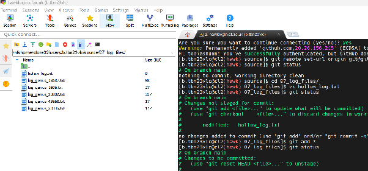

And when you press save, it will save the file back to hawk. This is what I did for the code:

`log_msg <- paste(Sys.time(), "Number of accessions to process:", length(accession_list))`

## **Github**

I moved files back and forth using git but it was a bit annoying that every time I did a `git push origin main` I was prompted to put in my git username and personal access token.

I set up SSH access instead. Instructions from Claude:

`ssh-keygen -t ed25519 -C <my email address>` (I think “ed25519” is an encryption code)

I pressed enter when I was prompted for information

Display the public key:

`cat ~/.ssh/id_ed25519.pub`

Then I went into Github and into Settings under my profile picture:

[figure not shown]

I chose SSH and GPG keys.

I created a new SSH key called Hawk and I pasted in the public key value which I had displayed on hawk.

I tested it using `ssh -T git@github.com` and this initially gave some worrying warnings like  
`The authenticity of host 'github.com (20.26.156.215)' can't be established.` (Github’s IP address)

Then asked if I wanted to continue, I said yes.  
`Warning: Permanently added 'github.com,20.26.156.215' (ECDSA) to the list of known hosts.`  
`Hi tobiasnunn! You've successfully authenticated, but GitHub does not provide shell access.`

Anyway Claude said this was okay and I can now pull and push without having to put in credentials, nice.

# Next steps

Now that I have my fasta files, I can move on to the first step of annotating them using eggNOG-mapper.

1. Remove the suppressed accessions from `01_inputs/04_fastas`✅
2. update the script so suppressed accessions fastas are never requested. This might be better to do in the `download_taxonomic_information_by_tax_ID` function. ❌
3. Extract the protein fastas from their rds file.
4. Update the contig labels to include the accession
5. Create ‘mega fastas’ by combing multiple fastas together
6. Email from hawk a different way, by including a line in the file
7. Think about how to monitor progress of the eggNOG search step, which is what the mega fastas will be used to do first.
8. explain why I have cut eggnog into 2 pieces

I created the script “suppressed_accession_remover.R” with the code to remove all suppressed accessions. However, when I ran the code on hawk, I decided to do it in the singularity image using the code:

`singularity exec ~/tidyverse_latest.sif R`

This created a sort of R console, that meant I could run the code 1 line at a time. This was good as it allowed me to make sure that it really had identified supressed accessions.

I have decided that in order to test whether the EggNOG-mapper “search” function works better with larger data sets, I am going to split the accessions into increasingly bigger groups, starting with an innitial 200 or so.

I created the script “protein_fasta_preperer”. This will eventually look much different, maybe be a function. For now, it does a test 200. It extracts the protein sequence from the rds and reads in the file, changing the contig label so that the accession ID is in the name. I have found some problems on hawk.

### Hit a snag

The problem with my script as written was it didn’t take into account a change I’d made 2 days ago to the NCBI_functions script, specifically [this commit:](https://github.com/tobiasnunn/undergrad_dissertation/commit/a9d7db651f3131c94838fa8fe779ffb6f77fc527)

and it’s this [line of code:](https://github.com/tobiasnunn/undergrad_dissertation/blob/06e20f06c7fc7614d967e4829c917c8ee9306ba0/00_scripts/R_scripts/NCBI_functions.R#L275)

This changed the structure of each of the fasta RDS files, to add in a top level node with the accession number in it - to make them easier to manage if I ever want to read them all back into one list object. This meant the new script wasn’t reading far enough down into the object, I needed to read genome_fasta <- fasta_data[[accession]]$protein not fasta_data$protein. I obviously hadn’t tested this on my machine so the few rds files that were there pre-dated the change.

After this I ran the script on my first 200 fastas and it errored on the 3rd one, saying writeLines(protein_fasta, output_file) : can only write character objects.

The 3rd accession didn’t have a protein fasta. So I added some error handling and then ran it again. It ran to the end but only 137 of the 200 accessions have protein fastas on the NCBI website. Needs a rethink, as only having 68.5% of samples in proteins is not really an acceptible number to just say “leave the ones that dont have a protein fasta. Meaning I am going to have to make my own genome -> protein conversion after all.

I therefore amended the script again to:

- output the genome fasta, not the protein fasta
- remove the file manipulation that inserts the accession into the header rows (marked with a > at the beginning). This step will need to wait.

With the redirection of that script, I now have all the genomic fastas in the 01_etc/04_etc/_working directory.

I think I will need to convert the genome fastas to protein fastas myself on hawk, using Prodigal. I have now found it - it has a capital P which is why I couldn’t find it in the list of modules before.

Right, so, here is the new TODO LIST:

1. setup the script that will turn genomic fastas into protein fastas on hawk
   1. this script will also update the contig labels to include the accession ID, this will be useful later on
2. combine the protein fastas into “mega-fastas” (group all contigs into 1 file, thus the necessity of ID in name)
   1. starting with an innitial batch of 200 for testing then making them bigger to test eggnog-mapper’s “search” pipeline
3. Run EggNOG-mapper search against the larger combined fastas
4. I will eventually have to explain why I am running the parts of EggNOG-mapper individually (its for speed, but its a bit more complex than that)

I created the script that turns genomic fastas into protein fastas. This is called “prodigal_test_script.sh” in the “Bash_scripts” section. For the innitial 200 accessions, it took 16 minutes and 55 seconds to complete, meaning just over 5 seconds per accession. At the end of that script is a line that uses “cat” to bring all the individual fastas into one file, which apparently makes the “search” stage of EggNOG-mapper run faster. As well as this, it changes the names of the contig labels to include the accession ID. Thus, when I separate them at the end, I will know what contigs belong to what accession.

I then created another script, this time ran on slurm, which conducts the “search” phase. I used code from Claude to optomise it, as it would take me a good long while to get familiar enough with the environment to create that alone. This script is called “eggnog_searcher.sh”. The parameters I used were:

`-m diamond--no_annot--no_file_comments-i /scratch/scw2160/TN_area/01_inputs/combined_proteins.faa--output_dir /scratch/scw2160/TN_area/02_outputs-o search_200_accessions--itype proteins--sensmode fast--pident 30--query_cover 50--evalue 1e-5--cpu 4`

These are the stats for that stage processing the 200:

`Total hits processed: 606665Total time: 1741 secs (29m)`

This outputs two files:

- search_200_accessions.emapper.hits
- search_200_accessions.emapper.seed_orthologs

I then ran the “annotation” stage using the script “eggnog_annotator.sh. I did not chose the excel parameter because I need to manipulate the text file that returns from it. The stats are:

`Total hits processed: 606665Total time: 2016 secs (33m)`

This creates the output file “annotation_200_accessions.emapper.annotations”, which can be enriched with the KEGG database to get KEGG Pathway information.

I observed that in the log file eggnogmapper writes an update message saying how many rows it has processed and how many queries per second it is performing:

`595500 2001.0973300933838 297.59 q/s (% mem usage: 23.50, % mem avail: 76.48)596000 2001.5944957733154 297.76 q/s (% mem usage: 23.50, % mem avail: 76.48)596500 2002.1451756954193 297.93 q/s (% mem usage: 23.50, % mem avail: 76.48)597000 2002.5639278888702 298.12 q/s (% mem usage: 23.50, % mem avail: 76.48)597500 2003.0883193016052 298.29 q/s (% mem usage: 23.50, % mem avail: 76.48)598000 2003.6249256134033 298.46 q/s (% mem usage: 23.50, % mem avail: 76.48)`

The thing to note is that it only ever got faster over time, there may be a limit to this, but I like to think it evidences Claude’s claim that bigger amounts of data is relatively faster.

It is important to note that EggNOG-mapper comprises the three sections I just covered. This means that in this configuration eggnogmapping these 200 samples took (1015s + 1741s + 2016s = 4772s) 80 minutes. In the past, I was lucky to get maybe 3 done in that same time, so my rate of opperation has rather exploded.

Next, I think it would be good to compare the content of these new annotations to the aforementioned old ones. Because, it is not very useful of them being quick if their quality is bad.

Then, it will be time to eggnog all the remaining accessions, after some upgrades to the scripts so that they can handle the increased workload (for example, things like resumability so I do not end up doing copies). I think the next batch size I will do is 1000.

# Results

# Conclusion

# Scientific Papers